# High Earners Using Public Transporation

#### Molly Wilson

Public transportation is extremely useful for commuters, especially those with a lower income who cannot afford to drive. I've been really aware of the lack of public transportation in the united states since I visited Amsterdam. Amsterdam is a beautiful city where everything is accessable by walking, biking, or public transportation. Cars on the roads are few and far between. It is so different from the United States, where only cities have any sort of public transportation, and it leaves a lot to be desired. This is what ultimately pushed me to do research on public transportation data in the United States. After finding and analyzing some data about public transportation usage in the United States, I found an interesting trend in the public transportation usage among higher earners. After discovering this trend, I decided to attempt to create a linear model that would best predict the number of high earners who used public transportation based on a number of factors that I will explain below.

```python
import pandas as pd
import plotly.express as px
import plotly.io as pio
pio.renderers.default = "jupyterlab"
import geopandas as gpd
import numpy as np
from sklearn import linear_model as lm
```

## The Walkability Dataset

The in this dataset, the walkability index for each block is calculated by using the formula $$(\dfrac{w}{3}) + (\dfrac{x}{3}) + (\dfrac{y}{6}) + (\dfrac{z}{6})$$

where  
$w =$ block group's ranked score for intersection density  
$x =$ block group's ranked score for proximity to transit stops  
$y =$ block group's ranked score for employment mix  
$z =$ block group's ranked score for employment and household mix

The [National Walkability Index: Methodology and User Guide](https://www.epa.gov/sites/default/files/2021-06/documents/national_walkability_index_methodology_and_user_guide_june2021.pdf) contains more information on the way that walkability data can be used and interpreted. You can also access the full dataset [here](https://catalog.data.gov/dataset/walkability-index1).

```python
walkability_df = pd.read_csv('downloads/EPA_SmartLocationDatabase_V3_Jan_2021_Final.csv')
```

## Access to Jobs and Workers via Transit Dataset

The boundaries for blocks are derived from the US Census 2010. Click [here](https://catalog.data.gov/dataset/access-to-jobs-and-workers-via-transit-download1) for more information about the dataset.

### Useful Features:

TrAccess_Index: An index of relative accessiblity compared to other blocks within the same metro region  
Pop_byTr: Total population able to access the block group within 45-minute transit and walking commute  
Pop_byTr_av: The weighted average Pop_byTr among all block groups within the same CBSA  
Pct_Pop_byTr: Total population able to access the block group within a 45-minute transit and walking commute as a percentage of total regional population  
HU_byTr: total housing units reachable within a 45 minute transit and walking commute  
HH_byTr: Households able to access the block group within a 45-minute transit and walking commute  
Wrks_byTr: Employed population able to access the block group within a 45-minute transit commute from their home location  
Pct_Wrks_byTr: Employed population able to access the block group within a 45-minute transit commute from their home location as a percentage of total regional employed population  
LoWgWrks_byTr: Number of low wage workersthat can reach the block group within a 45 minute transit commute  
MeWgWrks_byTr: Number of medium-wage workers that can reach the block group within a 45 minute transit commute  
HiWgWrks_byTr: Number of high-wage workers that can reach the block group within a 45-minute transit commute  
Jobs_byTr: Total jobs reachable within a 45-minute transit and walking commute  
Pct_Jobs_byTr: Total jobs reachable within a 45-minute transit and walking commute as a percentage of total regional jobs

```python
sld = gpd.read_file('Downloads/SLD_trans45/SLD_Trans45.gdb')
```

```python
# cut out hawaii so that we are only looking at mainland us
sld = sld[sld.CBSA_Name != "Honolulu, HI"]
```

After reading the data from the the gdb file, I removed all of the data about Hawaii to restrict the data to the mainland US because that is what I'm interested in. I then displayed the data on a map so I could get an idea of what the data looked like and where it was collected. I learned from this data that most places included in the data had a low percentage of workers who could use public transportation to get to work. I also learned that there aren't many places in the United States included in this dataset. This makes sense because not many places in the United States have public transportation at all. Since only a select few places have data, I need to be aware that the data may be biased toward places that actually have public transporation and don't represent the whole country.

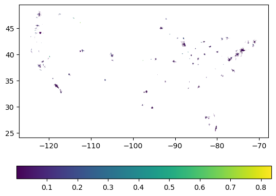

```python
sld.plot(column = "Pct_Wrks_byTr", legend=True, legend_kwds={'orientation': 'horizontal'})
```

## Data Processing

I want to combine the walkability and public transportation access datasets so that I can map them both as well as find patterns in the data. I will merge them along the GEOID10 column since they both have one.

```python
# change datatype to float so that the datatypes will be compatable
new_ID = []
for id in list(sld['GEOID10']):
    new_ID.append(float(id))
sld['GEOID10'] = new_ID
```

```python
df = pd.merge(sld, walkability_df, how='inner', on = 'GEOID10')
```

I normalized all of the data in the features that I mentioned in my description of the datasets so that the scales of all of those data points will be the same.

```python
# I am going to write a function that will normalize the feature of the dataframe that I give it
def normalize(df, feature):
    lst = list(df[feature])
    sorted_lst = sorted(list(df[~pd.isnull(df[feature])][feature]))
    mini = sorted_lst[0]
    maxi = sorted_lst[len(sorted_lst) - 1]
    ran = maxi - mini
    for i in range(len(lst)):
        #if lst[i] != np.nan:
        lst[i] = (lst[i] - mini)/ran
    df[feature + '_norm'] = lst
```

```python
# from the Walkability dataset, I am going to normalize 'NatWalkInd'
features = ['NatWalkInd', 'TrAccess_Index', 'Pop_byTr', 'Pop_byTr_av', 'Pct_Pop_byTr', 'HU_byTr', 'HH_byTr', 'Wrks_byTr', 'Pct_Wrks_byTr',
            'LoWgWrks_byTr', 'MeWgWrks_byTr', 'HiWgWrks_byTr', 'Jobs_byTr', 'Pct_Jobs_byTr']
for feature in features:
    normalize(df, feature)
```

## Data Visualization and Exploratory Data Analysis

This is where I learned about the interesting trend in high wage workers' access to public transportation in comparison to low and medium wage workers' access.

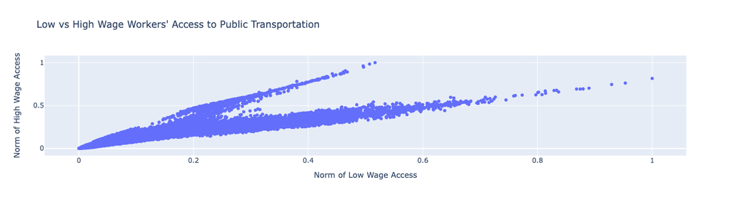

```python
fig = px.scatter(df, y = 'HiWgWrks_byTr_norm', x = 'LoWgWrks_byTr_norm', title = "Low vs High Wage Workers' Access to Public Transportation",
                labels= {
                    'HiWgWrks_byTr_norm': 'Norm of High Wage Access',
                    'LoWgWrks_byTr_norm': 'Norm of Low Wage Access'
                })
fig.show()
```

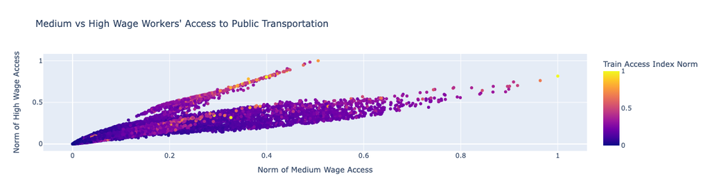

```python
fig = px.scatter(df, y = 'HiWgWrks_byTr_norm', x = 'MeWgWrks_byTr_norm', color='TrAccess_Index_norm', title = "Medium vs High Wage Workers' Access to Public Transportation",
                labels= {
                    'HiWgWrks_byTr_norm': 'Norm of High Wage Access',
                    'MeWgWrks_byTr_norm': 'Norm of Medium Wage Access',
                    'TrAccess_Index_norm': 'Train Access Index Norm'
                })
fig.show()
```

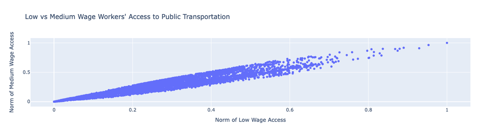

```python
fig = px.scatter(df, x = 'LoWgWrks_byTr_norm', y = 'MeWgWrks_byTr_norm', title = "Low vs Medium Wage Workers' Access to Public Transportation",
                labels= {
                    'LoWgWrks_byTr_norm': 'Norm of Low Wage Access',
                    'MeWgWrks_byTr_norm': 'Norm of Medium Wage Access'
                })
fig.show()
```

The correlation between medium and low wage workers' access to work by public transportation is extremely linear while the correlation between high wage and medium and low wage workers' access to work by public transport is mostly linear, but the linear model splits at around the 0.2 norm of low and medium wage workers with access to work via public transportation. We can see from the coloring on the second graph that the train access Index seems to explain some of this split, with the higher portion having a higher train access index.

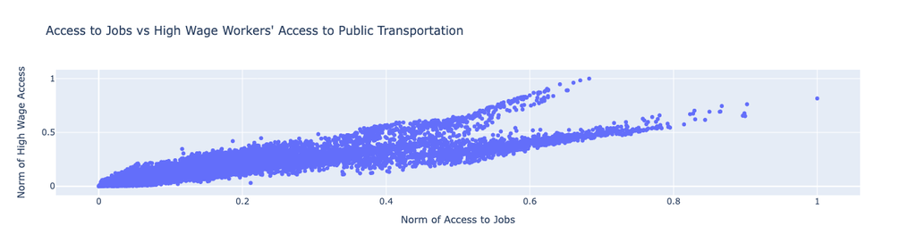

```python
fig = px.scatter(df, x = 'Jobs_byTr_norm', y = 'HiWgWrks_byTr_norm', title = "Access to Jobs vs High Wage Workers' Access to Public Transportation",
                labels= {
                    'Jobs_byTr_norm': 'Norm of Access to Jobs',
                    'HiWgWrks_byTr_norm': 'Norm of High Wage Access'
                })
fig.show()
```

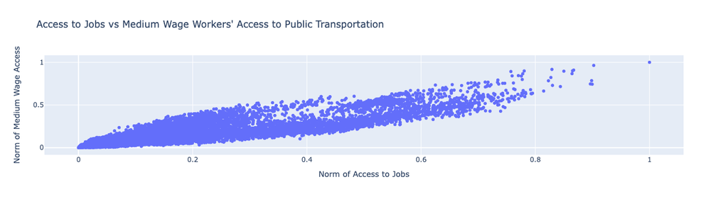

```python
fig = px.scatter(df, x = 'Jobs_byTr_norm', y = 'MeWgWrks_byTr_norm', title = "Access to Jobs vs Medium Wage Workers' Access to Public Transportation",
                labels= {
                    'Jobs_byTr_norm': 'Norm of Access to Jobs',
                    'MeWgWrks_byTr_norm': 'Norm of Medium Wage Access'
                })
fig.show()
```

There is a clear split in the points around .4 Jobs by Transportation norm of High wage workers where there isn't for medium wage workers. I want to see why this is. I am going to make several graphs with colors representing different variables and seeing which ones correlate to the split.

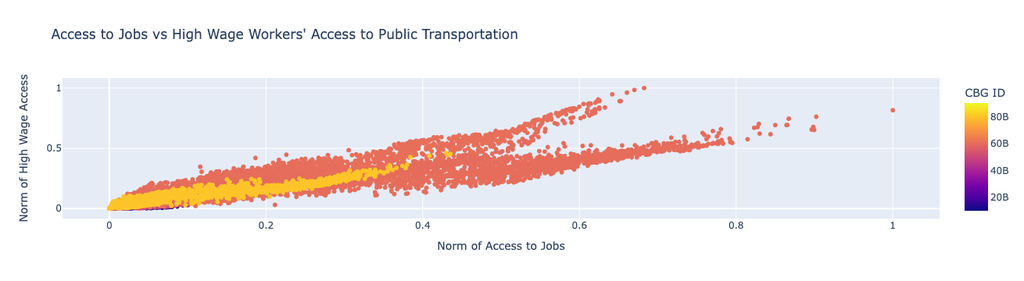

```python
fig = px.scatter(df, x = 'Jobs_byTr_norm', y = 'HiWgWrks_byTr_norm', color='CBG_ID', title = "Access to Jobs vs High Wage Workers' Access to Public Transportation",
                labels= {
                    'Jobs_byTr_norm': 'Norm of Access to Jobs',
                    'HiWgWrks_byTr_norm': 'Norm of High Wage Access',
                    'CBG_ID': 'CBG ID'
                })
fig.show()
```

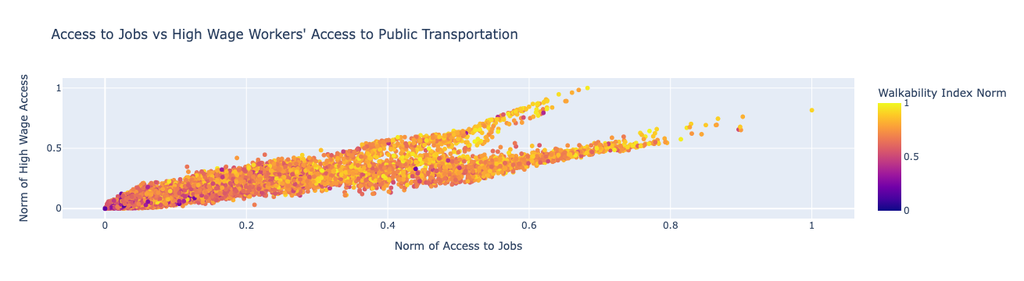

```python
fig = px.scatter(df, x = 'Jobs_byTr_norm', y = 'HiWgWrks_byTr_norm', color='NatWalkInd_norm', title = "Access to Jobs vs High Wage Workers' Access to Public Transportation",
                labels= {
                    'Jobs_byTr_norm': 'Norm of Access to Jobs',
                    'HiWgWrks_byTr_norm': 'Norm of High Wage Access',
                    'NatWalkInd_norm': 'Walkability Index Norm'
                })
fig.show()
```

The above graphs make it clear that differences in location and walkability index do not cause this split in the data. </br > The graphs below make it clear that a higher train access index correlates to the split in high wage workers access to work via public transportation, showing that a higher access index means that more high wage earners can use public transportation than in areas with lower public transporation accessability, which makes sense. We can see from the graphs showing the relationship low wage workers, job access, and population with access to public transportation that the opposite is true for lower wage workers, which seems counterintuitive. I didn't look further into the reason for this in this project, but it would be an interesting place to do future analysis.

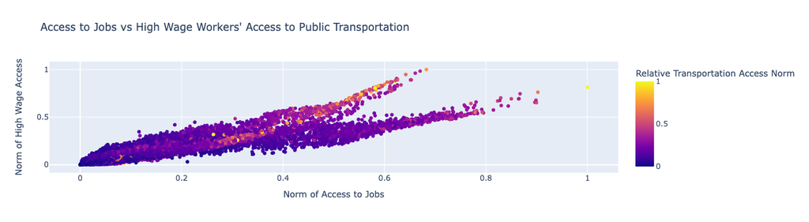

```python
fig = px.scatter(df, x = 'Jobs_byTr_norm', y = 'HiWgWrks_byTr_norm', color='TrAccess_Index_norm', title = "Access to Jobs vs High Wage Workers' Access to Public Transportation",
                labels= {
                    'Jobs_byTr_norm': 'Norm of Access to Jobs',
                    'HiWgWrks_byTr_norm': 'Norm of High Wage Access',
                    'TrAccess_Index_norm': 'Relative Transportation Access Norm'
                })
fig.show()
```

We can see that a higher number of the people having access to public transportation causes a lower amout of higher income workers to take public transporation than when there is a lower number of people with access to public transportation. The same cannot be said about lower wage workers. The percentage of the population that can access transportation to work has a similar correlation to the Relative Transportation Access norm. Based on the graph I made below showing the relationship between the Population with access to public transportation and the percentage of the population with access to public transporation, they are not linearly correlated. They seem to be more dependent on location, which makes sense. This tells me that the percetage of the population with access to transportation is more valuable to me as a predictor of high wage workers taking public transportation to work because it is easier to compare between areas with different populations.

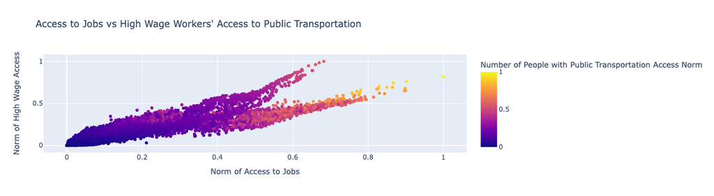

```python
fig = px.scatter(df, x = 'Jobs_byTr_norm', y = 'HiWgWrks_byTr_norm', color='Pop_byTr_norm', title = "Access to Jobs vs High Wage Workers' Access to Public Transportation",
                labels= {
                    'Jobs_byTr_norm': 'Norm of Access to Jobs',
                    'HiWgWrks_byTr_norm': 'Norm of High Wage Access',
                    'Pop_byTr_norm': 'Number of People with Public Transportation Access Norm'
                })
fig.show()
```

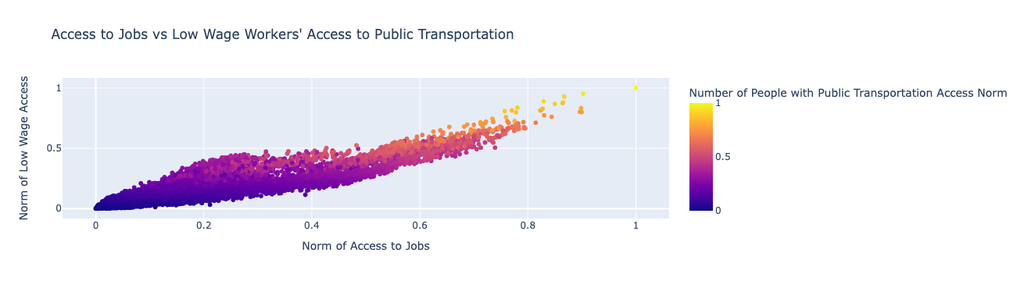

```python
fig = px.scatter(df, x = 'Jobs_byTr_norm', y = 'LoWgWrks_byTr_norm', color='Pop_byTr_norm', title = "Access to Jobs vs Low Wage Workers' Access to Public Transportation",
                labels= {
                    'Jobs_byTr_norm': 'Norm of Access to Jobs',
                    'LoWgWrks_byTr_norm': 'Norm of Low Wage Access',
                    'Pop_byTr_norm': 'Number of People with Public Transportation Access Norm'
                })
fig.show()
```

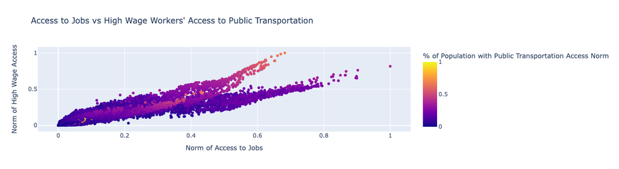

```python
fig = px.scatter(df, x = 'Jobs_byTr_norm', y = 'HiWgWrks_byTr_norm', color='Pct_Pop_byTr_norm', title = "Access to Jobs vs High Wage Workers' Access to Public Transportation",
                labels= {
                    'Jobs_byTr_norm': 'Norm of Access to Jobs',
                    'HiWgWrks_byTr_norm': 'Norm of High Wage Access',
                    'Pct_Pop_byTr_norm': '% of Population with Public Transportation Access Norm'
                })
fig.show()
```

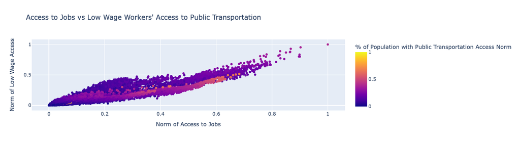

```python
fig = px.scatter(df, x = 'Jobs_byTr_norm', y = 'LoWgWrks_byTr_norm', color='Pct_Pop_byTr_norm', title = "Access to Jobs vs Low Wage Workers' Access to Public Transportation",
                labels= {
                    'Jobs_byTr_norm': 'Norm of Access to Jobs',
                    'LoWgWrks_byTr_norm': 'Norm of Low Wage Access',
                    'Pct_Pop_byTr_norm': '% of Population with Public Transportation Access Norm'
                })
fig.show()
```

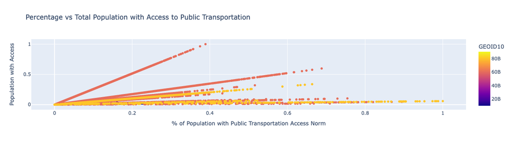

```python
fig = px.scatter(df, y = 'Pop_byTr_norm', x = 'Pct_Pop_byTr_norm', color='GEOID10', title = "Percentage vs Total Population with Access to Public Transportation",
                labels = {
                    'Pop_byTr_norm': 'Population with Access',
                    'Pct_Pop_byTr_norm': '% of Population with Public Transportation Access Norm'
                })
fig.show()
```

## Data Analysis

As I mentioned before the split in the model for high wage workers is really interesting, so I'm going to create a linear regression model with multiple variables to figure out what the best predictors for this model are and find a linear equation that best predicts the norm of the number of high wage workers with access to their jobs via public transportation.

```python
train = df[:20000]
test = df[20000:]
```

```python
# length of shortest array of variables below
MIN = 10060
Y = train[~pd.isnull(train['HiWgWrks_byTr_norm'])]['HiWgWrks_byTr_norm'].to_numpy().reshape(-1, 1)[:MIN]
var1 = train[~pd.isnull(train['Pct_Jobs_byTr_norm'])]['Pct_Jobs_byTr_norm'].to_numpy().reshape(-1, 1)
var2 = train[~pd.isnull(train['LoWgWrks_byTr_norm'])]['LoWgWrks_byTr_norm'].to_numpy().reshape(-1, 1)
var3 = train[~pd.isnull(train['Pct_Pop_byTr_norm'])]['Pct_Pop_byTr_norm'].to_numpy().reshape(-1, 1)
var4 = train[~pd.isnull(train['TrAccess_Index_norm'])]['TrAccess_Index_norm'].to_numpy().reshape(-1, 1)
var5 = train[~pd.isnull(train['MeWgWrks_byTr_norm'])]['MeWgWrks_byTr_norm'].to_numpy().reshape(-1, 1)
X = np.c_[np.ones((MIN,1)),var1[:MIN], var2[:MIN], var3[:MIN], var4[:MIN], var5[:MIN]]
```

```python
# preform linear regression and calculate the coefficients of the linear regression model as theta
theta = np.linalg.inv(X.T.dot(X)).dot(X.T).dot(Y)
```

```python
TMIN = 3812
Y_t = train[~pd.isnull(train['HiWgWrks_byTr_norm'])]['HiWgWrks_byTr_norm'].to_numpy().reshape(-1, 1)[:TMIN]
tvar1 = test[~pd.isnull(test['Pct_Jobs_byTr_norm'])]['Pct_Jobs_byTr_norm'].to_numpy().reshape(-1, 1)
tvar2 = test[~pd.isnull(test['LoWgWrks_byTr_norm'])]['LoWgWrks_byTr_norm'].to_numpy().reshape(-1, 1)
tvar3 = test[~pd.isnull(test['Pct_Pop_byTr_norm'])]['Pct_Pop_byTr_norm'].to_numpy().reshape(-1, 1)
tvar4 = test[~pd.isnull(test['TrAccess_Index_norm'])]['TrAccess_Index_norm'].to_numpy().reshape(-1, 1)
tvar5 = test[~pd.isnull(test['MeWgWrks_byTr_norm'])]['MeWgWrks_byTr_norm'].to_numpy().reshape(-1, 1)
X_t = np.c_[tvar1[:TMIN], tvar2[:TMIN], tvar3[:TMIN], tvar4[:TMIN], tvar5[:TMIN]]
```

```python
# function that predicts the HiWgWrks_byTr_norm value
def Hi_Wg_Predict(theta, jobs=0, low=0, pop=0, access=0, med=0):
    return theta[0] + jobs * theta[1] + low * theta[2] + pop * theta[3] + access * theta[4] + med * theta[5]
```

```python
# calculate the squared error loss for each value in the test data
loss = []
for row, y in zip(X_t, Y_t):
    y_hat = Hi_Wg_Predict(theta, row[0], row[1], row[2], row[3], row[4])
    sq_loss = ((y_hat - y) ** 2) / 2
    loss.append(float(sq_loss))
```

```python
# make the actual values for the x-axis the correct datatype to plot
x_axis = list(Y_t)
for i in range(len(x_axis)):
    x_axis[i] = float(x_axis[i])
```

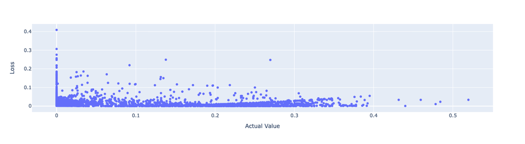

```python
px.scatter(x=x_axis, y=loss, labels={'x':'Actual Value', 'y':'Loss'})
```

From this analysis, we can see that the linear model is pretty accurate for higher amounts of high earners who have access to public transportation, but is extremely variable for lower numbers of high earners.  
This model is not satisfactory, so I tried to see how each of the individual variables were affecting the model.  
Based on the analysis below, the low wage and medium wage data creates a smooth parabolic function that has a clear minimum. We can also see that the loss gets much larger around where the norm of the number of high wage workers reaches around 0.3 - 0.35 which makes sense because that is where the split in the graph with high wage workers' access to work via public transportation as a dependency. Based on this information, I am going to continue by using these two variables, but I'm going to add in norm of the percentage of the population with access to work via public transportation because it seemed to be the best predictor of that split based on the graphs I made in the data visualization and exploratory analysis section.

```python
X = np.c_[np.ones((MIN,1)),var2[:MIN], var5[:MIN]]
```

```python
# preform linear regression for the two selected variables and calculate the coefficients of the linear regression model as theta2
theta2 = np.linalg.inv(X.T.dot(X)).dot(X.T).dot(Y)
```

```python
X_t = np.c_[tvar2[:TMIN], tvar5[:TMIN]]
```

```python
# function that predicts the HiWgWrks_byTr_norm value
def Hi_Wg_Predict2(theta, low, med):
    return theta[0] + low * theta[1] + med * theta[2]
```

```python
# calculate the squared error loss for each value in the test data
loss = []
for row, y in zip(X_t, Y_t):
    y_hat = Hi_Wg_Predict2(theta2, row[0], row[1])
    sq_loss = ((y_hat - y) ** 2) / 2
    loss.append(float(sq_loss))
```

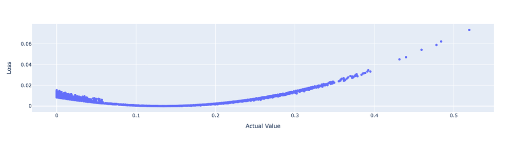

```python
px.scatter(x=x_axis, y=loss, labels={'x':'Actual Value', 'y':'Loss'})
```

```python
X = np.c_[np.ones((MIN,1)), var2[:MIN], var3[:MIN], var5[:MIN]]
```

```python
# preform linear regression and calculate the coefficients of the linear regression model as theta
theta3 = np.linalg.inv(X.T.dot(X)).dot(X.T).dot(Y)
```

```python
X_t = np.c_[tvar2[:TMIN], tvar3[:TMIN], tvar5[:TMIN]]
```

```python
# function that predicts the HiWgWrks_byTr_norm value
def Hi_Wg_Predict3(theta, low, pop, med):
    return theta[0] + low * theta[1] + pop * theta[2] + med * theta[3]
```

```python
# calculate the squared error loss for each value in the test data
loss = []
for row, y in zip(X_t, Y_t):
    y_hat = Hi_Wg_Predict3(theta3, row[0], row[1], row[2])
    sq_loss = ((y_hat - y) ** 2) / 2
    loss.append(float(sq_loss))
```

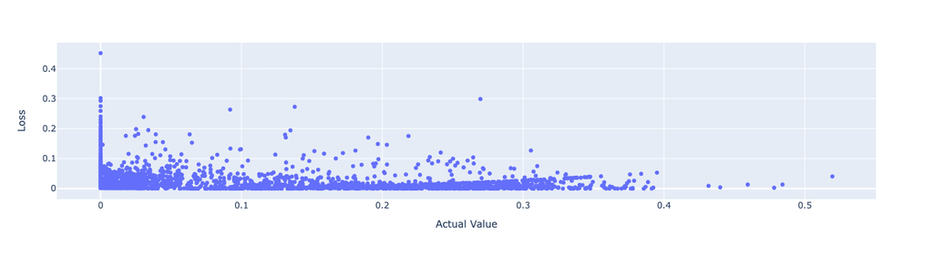

```python
px.scatter(x=x_axis, y=loss, labels={'x':'Actual Value', 'y':'Loss'})
```

```python
X_t = np.c_[tvar1[:TMIN], tvar2[:TMIN], tvar3[:TMIN], tvar4[:TMIN], tvar5[:TMIN]]
```

```python
# calculate the squared error loss for each value in the test data
loss = []
for row, y in zip(X_t, Y_t):
    if y > 0.25:
        y_hat = Hi_Wg_Predict3(theta3, row[1], row[2], row[4])
    else:
        y_hat = Hi_Wg_Predict2(theta2, row[2], row[4])
    sq_loss = ((y_hat - y) ** 2) / 2
    loss.append(float(sq_loss))
```

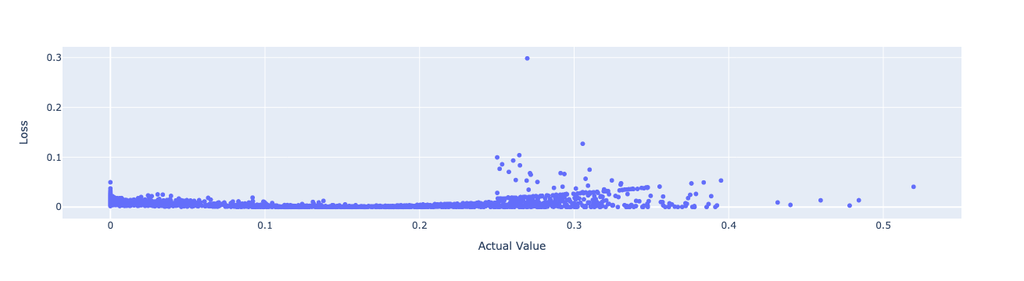

```python
px.scatter(x=x_axis, y=loss, labels={'x':'Actual Value', 'y':'Loss'})
```

```python
# calculate the squared error loss for each value in the test data
loss = []
for row, y in zip(X_t, Y_t):
    y_hat3 = Hi_Wg_Predict3(theta3, row[1], row[2], row[4])
    y_hat2 = Hi_Wg_Predict2(theta2, row[2], row[4])
    if y_hat2 > 0.25 and y_hat3 > 0.25:
        sq_loss = ((y_hat3 - y) ** 2) / 2
    else:
        sq_loss = ((y_hat2 - y) ** 2) / 2

    loss.append(float(sq_loss))
```

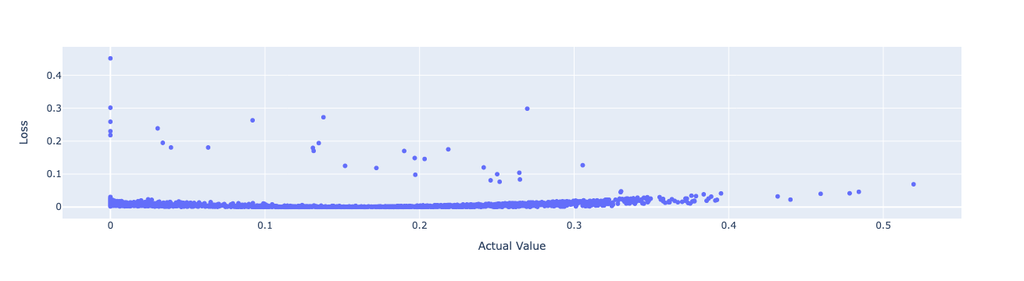

```python
px.scatter(x=x_axis, y=loss, labels={'x':'Actual Value', 'y':'Loss'})
```

```python
# calculate the squared error loss for each value in the test data
loss = []
for row, y in zip(X_t, Y_t):
    y_hat3 = Hi_Wg_Predict3(theta3, row[1], row[2], row[4])
    y_hat2 = Hi_Wg_Predict2(theta2, row[2], row[4])
    if y_hat2 > 0.25:
        sq_loss = ((y_hat3 - y) ** 2) / 2
    else:
        sq_loss = ((y_hat2 - y) ** 2) / 2

    loss.append(float(sq_loss))
```

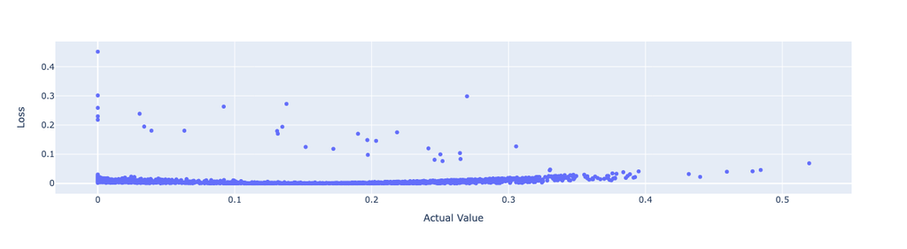

```python
px.scatter(x=x_axis, y=loss, labels={'x':'Actual Value', 'y':'Loss'})
```

```python
# calculate the squared error loss for each value in the test data
loss = []
for row, y in zip(X_t, Y_t):
    y_hat3 = Hi_Wg_Predict3(theta3, row[1], row[2], row[4])
    y_hat2 = Hi_Wg_Predict2(theta2, row[2], row[4])
    if y_hat3 > 0.25:
        sq_loss = ((y_hat3 - y) ** 2) / 2
    else:
        sq_loss = ((y_hat2 - y) ** 2) / 2

    loss.append(float(sq_loss))
```

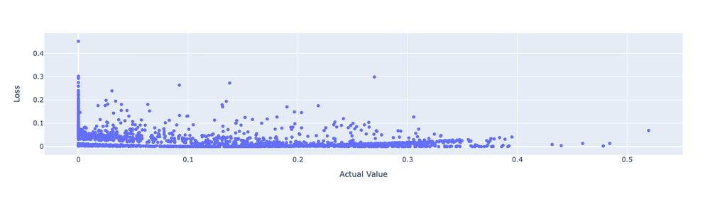

```python
px.scatter(x=x_axis, y=loss, labels={'x':'Actual Value', 'y':'Loss'})
```

Based on the scatter plots of losses that I made, it is best to use either the prediction of the two variable function or both predictions. Using only the prediction of the 3 variable function as a threshhold does not appear to be as accurate.

## Conclusion

I determined that the best model for predicting the number of high wage workers with access to work via public transportation was $$ \hat{y} = \begin{cases} p_1 & \text{if $p_1$ < 0.25}\\ p_2 & \text{if $p_1$ $\geq$ 0.25} \end{cases} $$ where $ \\ p_1 = 0.1296 + 0.2176x_1 - 0.1333x_2 \\ p_2 = 0.0645 + 0.2214x_1 - 0.1566x_2 + 0.9923x_3 $ and $ \\ x_1 = \text{the norm of the number of low wage workers with access to work via public transportation} \\ x_2 = \text{the norm of the number of medium wage workers with access to work via public transportation} \\ x_3 = \text{the norm of the percentage of the regional population able to access work via public transportation} $

I chose to use the function with only 3 predictors over the one with 5 to simplify the calculations since they both had very similar prediction results. I chose to only compare the result of only function $p_1$ to compare to the threshold to simplify calculations as well.

It makes sense that the best predictors for the number of high wage workers with access to work via public transportation would be the number of other workers with access to work via public transportation. The interesting thing about this data was that the number of high wage workers with access to public transportation split at around the 0.3 norm spot and needed a different linear equation to predict it. It was interesting that this split was only present in the high wage worker data and not the low and medium wage workers'.

I think the reason for this may be that people with more money are more able to live closer to their jobs in expensive areas rather than having to commute over a long distance, especially in expensive coastal cities that tend to have public transportation. This is just an idea and more research will need to be done to legitimize this claim.